# Data Visualization - C&A, IIT Guwahati

## Data Visualization with Python

[figure not shown]

A tutorial by [Rishabh Agrawal](https://www.linkedin.com/in/r1shbh).

Mail us at caciitg@gmail.com with Subject: Data Viz with Python if you have any suggestions/find error in the material.

# Introduction

Navigate Down

- **Please view the material on Desktop for better experience**
- The following slide/notebook will take you through the process of Data Visualization with Python.
- We will use [matplotlib](https://matplotlib.org/) and [seaborn](https://seaborn.pydata.org/) libraries of Python.
- We will explore three types of explorations - Univariate, Bivariate and Multivariate Explorations.

### Note:

- These slides are completely prepared on Jupyter notebooks. Please refer to [this blog](https://medium.com/@mjspeck/presenting-code-using-jupyter-notebook-slides-a8a3c3b59d67) to know how this can be done.
- Please use the navigation button at **bottom right** to navigate through the content.

#### So are you excited?

### Note: My color palette to be used in the tutorial

I believe in aesthetics

```python
# My colors to be used in exploration
green1 = [22/256, 111/256, 76/256]
blue1 = [29/256, 82/256, 120/256]
green2 = [0/256, 83/256, 47/256]
blue2 = [38/256, 51/256, 86/256]
green3 = [50/256, 199/256, 127/256]
blue3 = [26/256, 196/256, 219/256]
red1 = [125/256, 25/256, 0/256]
red2 = [178/256, 24/256, 71/256]
```

You will see the above colors used in most of my plots

# Why Data Visualization is Important?

Navigate Down

```python
data.head()
```

|  | Location | Year | Kilometers_Driven | Fuel_Type | Transmission | Owner_Type | Seats | Price | Brand | Model | Submodel | Mileage_Value | Engine_CC | Power_bhp |
| --- | --- | --- | --- | --- | --- | --- | --- | --- | --- | --- | --- | --- | --- | --- |
| 0 | Mumbai | 2010 | 72000 | CNG | Manual | First | 5.0 | 1.75 | Maruti | Wagon | R LXI CNG | 26.60 | 998.0 | 58.16 |
| 1 | Pune | 2015 | 41000 | Diesel | Manual | First | 5.0 | 12.50 | Hyundai | Creta | 1.6 CRDi SX Option | 19.67 | 1582.0 | 126.20 |
| 2 | Chennai | 2011 | 46000 | Petrol | Manual | First | 5.0 | 4.50 | Honda | Jazz | V | 18.20 | 1199.0 | 88.70 |
| 3 | Chennai | 2012 | 87000 | Diesel | Manual | First | 7.0 | 6.00 | Maruti | Ertiga | VDI | 20.77 | 1248.0 | 88.76 |
| 4 | Coimbatore | 2013 | 40670 | Diesel | Automatic | Second | 5.0 | 17.74 | Audi | A4 | New 2.0 TDI Multitronic | 15.20 | 1968.0 | 140.80 |

**Does only viewing the table above gives you much about the data? No!**

```python
data.describe()
```

|  | Year | Kilometers_Driven | Seats | Price | Mileage_Value | Engine_CC | Power_bhp |
| --- | --- | --- | --- | --- | --- | --- | --- |
| count | 6019.000000 | 6.019000e+03 | 6019.000000 | 6019.000000 | 6019.000000 | 6019.000000 | 6019.000000 |
| mean | 2013.358199 | 5.873838e+04 | 5.234923 | 9.479468 | 18.128603 | 1611.573517 | 110.538614 |
| std | 3.269742 | 9.126884e+04 | 0.960660 | 11.187917 | 4.594784 | 612.465615 | 56.003179 |
| min | 1998.000000 | 1.710000e+02 | -1.000000 | 0.440000 | -1.000000 | -1.000000 | -1.000000 |
| 25% | 2011.000000 | 3.400000e+04 | 5.000000 | 3.500000 | 15.160000 | 1197.000000 | 74.000000 |
| 50% | 2014.000000 | 5.300000e+04 | 5.000000 | 5.640000 | 18.150000 | 1493.000000 | 91.100000 |
| 75% | 2016.000000 | 7.300000e+04 | 5.000000 | 9.950000 | 21.100000 | 1969.000000 | 138.030000 |
| max | 2019.000000 | 6.500000e+06 | 10.000000 | 160.000000 | 33.540000 | 5998.000000 | 560.000000 |

**Does the summary statistics gives you a better idea about the dataset now? Umm, something better!**

**Now let's see a visual of a pairplot between 3 variables**

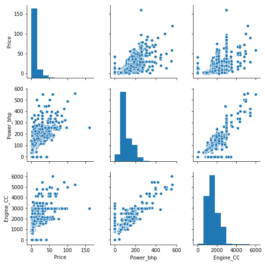

```python
sns.pairplot(data[['Price', 'Power_bhp', 'Engine_CC']]);
```

**Visualization hopefully must have given you a little better idea than the tables above**

### Takeaway points:

- As humans, we cannot interpret the dataset with just having a glance at the large tables of values.
- Summary statistics (mean, standard deviations, median, etc) are a little better tools for understanding the data.
- However, fun fact: We can have two datasets having **same means, same variance and same correlations**, yet being totally completely different. Check out [this fun blog](https://medium.com/@caciitg/why-are-visualizations-important-anyway-d356e14a2cde)!
- Bascially, humans are good visual learners. And therefore, visualizations are an **important tool** to get an initial feel for your dataset.

# Pre-Requisites: Types of Data

Data Visualization is highly dependent on you knowing about the digram below. If you don't know about it, kindly go through [this](https://towardsdatascience.com/data-types-in-statistics-347e152e8bee)

[figure not shown]

# Univariate Explorations

[figure not shown]

- In this section, we will learn about visualizing "one feature" at a time.
- These are highly dependent on the **data type** for which you need a plot.
- Univariate explorations are one of the **starting points** of Data Visualizations. They give you an idea about features themselves, without trying to understand their behavior with other features.

**So let's dive into it!**

# Univariate Explorations

### Case 1: Numerical Continous Data (Histogram)

Navigate Down

## Histogram using Seaborn

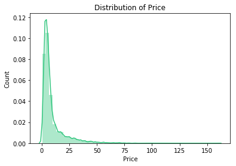

```python
# Price feature (Numerical)
# Option 1: Via Seaborn
sns.distplot(data.Price, color=green3)
plt.title('Distribution of Price');
plt.ylabel('Count');
```

## Histogram using Matplotlib

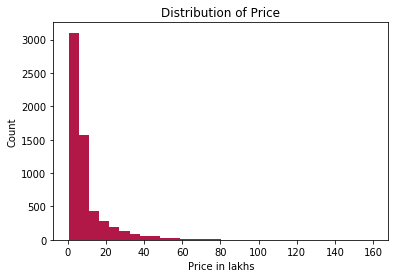

```python
# Price feature (Numerical)
# Option 2: Via Matplotlib
plt.hist(data.Price, bins=30, color=red2);
plt.title('Distribution of Price')
plt.xlabel('Price in lakhs')
plt.ylabel('Count');
```

### Some things to note:

- Always include the **title, xlabel and ylabel** for a plot.
- Always end the cell with a ";" in cells in which your are writing commands for a plot. If you don't end with a ";", you can can unwanted text like the following:

### What Happens if you don't end with ;

```
Text(0,0.5,'Count')
```

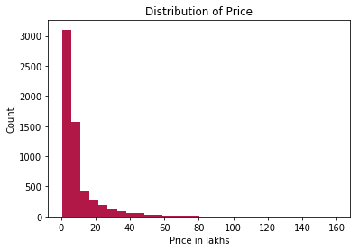

```python
# Option 2: Via Matplotlib
plt.hist(data.Price, bins=30, color=red2);
plt.title('Distribution of Price')
plt.xlabel('Price in lakhs')
plt.ylabel('Count')
```

### Number of Bins:

- Default number of bins are 10. You can vary them by passing an attribute "bins" to the plt or distplot functions.
- Increasing the bins increases information but also increases noise. Decreasing the bins loses some information, but also have reduced noise. You will need to find an optimal number of bins by varying it and find which is appropriate for your data.

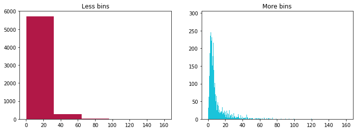

```python
fig = plt.figure(figsize=[12, 4])
ax = fig.add_subplot(1, 2, 1)
ax.hist(data.Price, bins=5, color=red2);
ax.set_title('Less bins')

ax = fig.add_subplot(1, 2, 2)
ax.hist(data.Price, bins=500, color=blue3);
ax.set_title('More bins');
```

# Univariate Explorations

### Additional Concepts

Navigate Down

## 1. Log Transformation

As we see that the Price is highly right skew, sometimes it is better to view a log transformation of the same

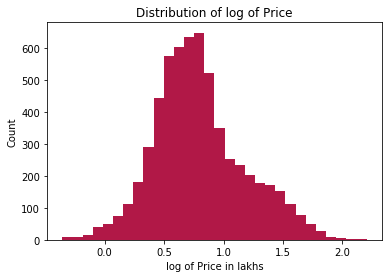

```python
# Observing log distribution
plt.hist(np.log10(data.Price), bins=30, color=red2);
plt.title('Distribution of log of Price')
plt.xlabel('log of Price in lakhs')
plt.ylabel('Count');
```

**Observe how a log(Price) follows a normal distribution**

## 2. Understanding Outliers

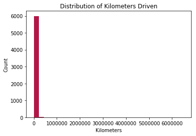

```python
# Observing outliers
plt.hist(data.Kilometers_Driven, bins=30, color=red2);
plt.title('Distribution of Kilometers Driven')
plt.xlabel('Kilometers')
plt.ylabel('Count');
```

**There are definietly some outliers there**

#### Zooming into the heart!

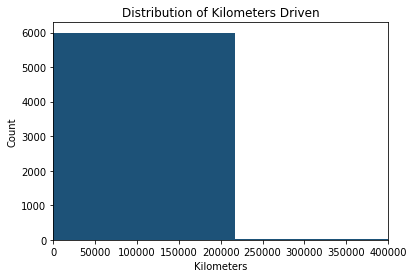

```python
# Using xlim
plt.hist(data.Kilometers_Driven, bins=30, color=blue1);
plt.title('Distribution of Kilometers Driven')
plt.xlabel('Kilometers')
plt.ylabel('Count');
plt.xlim(-1, 400000);
```

**Should we conclude that kilometers are generally uniform?? No!!**  
Remember, we talked about varying bins? Losing information? Check out next subslide!

## Increasing bins to capture more information

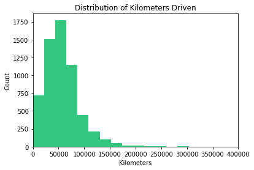

```python
# Increasing bins
plt.hist(data.Kilometers_Driven, bins=300, color=green3);
plt.title('Distribution of Kilometers Driven')
plt.xlabel('Kilometers')
plt.ylabel('Count');
plt.xlim(-1, 400000);
```

# Univariate Explorations

Navigate Down

## Bar Plot (Basic)

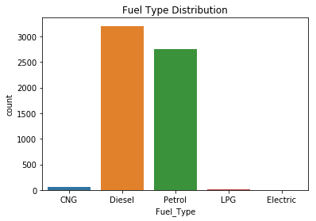

```python
# Fuel Type: Categorical feature
sns.countplot(data=data, x='Fuel_Type')
plt.title('Fuel Type Distribution');
```

## Some problems in above graph:

- **Use of colors**: By default, a countplot uses a different color for each of the categories involved in the given feature. It might look fancy and beatiful to some, but an important question to ask is: **Is it required? No!**. Imagine this: The x axis already lists the different categories of plot (i.e CNG, Diesel, Petrol, etc). But we still are using a **different color scheme** for each. **Rule of thumb: For every color introduced in the plot, you will also need to include the legend describing the meaning of those colors**. Here, the introduction of legends would be **redundant.** Because, the x-axis is already doing that job. In general, try to plot your graphs as much as possible in **unicolor.**
- **The order of bars**: Because we are dealing with **nominal data**, the order of the categories do not matter. So, we have the liberty to change the order by default. **Quick question: What do you think would be a good ordering scheme here?**

**Check the next sub-slide to check out an improved version of the plot**

## Bar Graph: Standard Practice

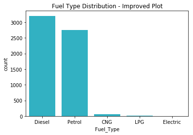

```python
# Bar chart: improved version
ordering = data['Fuel_Type'].value_counts().sort_values(ascending=False).index
sns.countplot(data=data, x='Fuel_Type', order=ordering, color=blue3)
plt.title('Fuel Type Distribution - Improved Plot');
```

### Another example

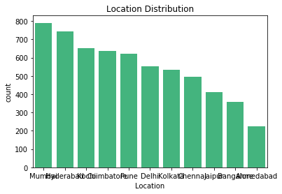

```python
# Location Feature
ordering = data['Location'].value_counts().sort_values(ascending=False).index
sns.countplot(data=data, x='Location', order=ordering, color=green3)
plt.title('Location Distribution');
```

**Oops: How to improve this? Check out!**

## Improved Version of Above Plot: Changing 'y'

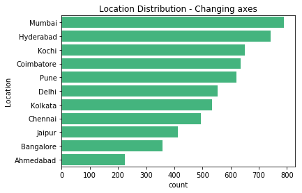

```python
# Option 1: Changing y ='Location'
ordering = data['Location'].value_counts().sort_values(ascending=False).index
sns.countplot(data=data, y='Location', order=ordering, color=green3)
plt.title('Location Distribution - Changing axes');
```

## Improving Above Plot: Rotating xticks

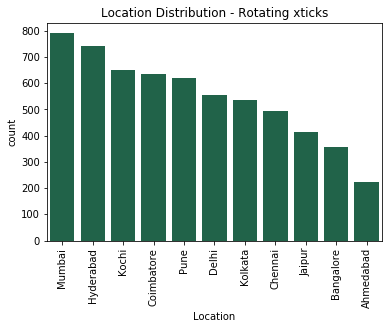

```python
# Option 2: Rotating xticks
ordering = data['Location'].value_counts().sort_values(ascending=False).index
sns.countplot(data=data, x='Location', order=ordering, color=green1)
plt.title('Location Distribution - Rotating xticks');
plt.xticks(rotation=90);
```

# Univariate Explorations

### Case 3: Discrete Data (Histogram with bin edges and width)

Navigate Down

- If you want to plot a discrete quantitative variable, it is possible to select either a histogram or a bar chart to depict the data.
- The histogram is the most immediate choice since the data is numeric, but there's one particular consideration to make regarding the bin edges. Since data points fall on set values, it can help to reduce ambiguity by putting bin edges between the actual values taken by the data.

# Bar Graph on Discrete feature

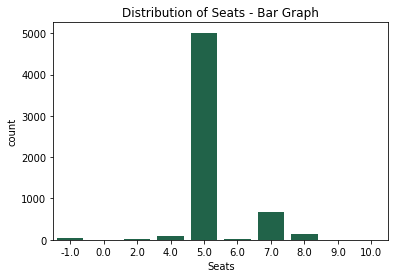

```python
# Seats Feature: What is we plot a Bar Chart?
sns.countplot(data=data, x='Seats', color=green1);
plt.title('Distribution of Seats - Bar Graph');
```

Looks good enough! But there's a problem. Imagine if we had cars with all seats vales as: 1, 3, 5, 6. In such a case, the countplot would just plot with x labels having 1,3,5 and 6. It won't consider 2 and 4. Which is a wrong practice!

**Note: Missing values were replaces with -1 previously while cleaning.**

# Using Histogram for Discrete Feature

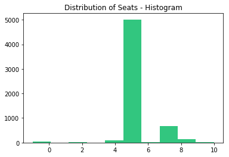

```python
# Stats Feature: Histogram
plt.hist(data.Seats, color=green3)
plt.title('Distribution of Seats - Histogram');
```

**Problems:**

- It seems as if the variables are continous (than discrete)
- The xlabels edges seem to be not matching

# Histogram for Discrete Feature: Standard Practice

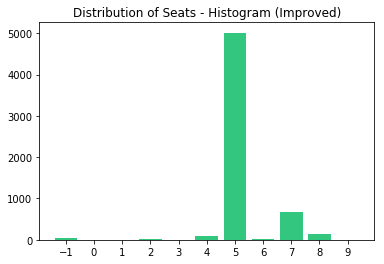

```python
# Seats Feature: How to plot a discerete variable?
ticks = np.arange(data.Seats.min(), data.Seats.max(), 1)
bin_edges = np.arange(data.Seats.min()-0.5, data.Seats.max()+0.5, 1)
plt.hist(data.Seats, color=green3, rwidth=0.8, bins=bin_edges)
plt.title('Distribution of Seats - Histogram (Improved)');
plt.xticks(ticks);
```

# Univariate Explorations

### Case 4: Categorical Ordinal Data (Bar Graph with order)

Navigate Down

## Bar Graph on Ordinal Feature

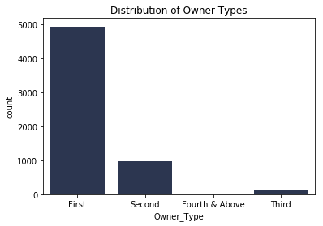

```python
# Owner_Type Feature
sns.countplot(data=data, x='Owner_Type', color=blue2)
plt.title('Distribution of Owner Types');
```

**Check the correct version on next subslide**

## Bar Graph on Ordinal Feature: Standard Practice

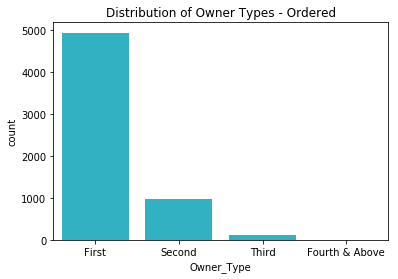

```python
# Owner_Type Feature
sns.countplot(data=data, x='Owner_Type', color=blue3, order=['First', 'Second', 'Third', 'Fourth & Above'])
plt.title('Distribution of Owner Types - Ordered');
```

- Always order your axis correctly with the actual ordinality.
- Here the graphs are naturaly decreasing order with their ordinality. But sometimes they might not. (e.g Count of Second > Third > First > Fourth & Above).
- In categorical nominal data, we could arrange the order on the basis of the decreasing count (there existed no particular order), but here WE SHOULD NOT!

# Univariate Exploration

## Summary

- **Numerical Continous**: Histogram
- **Categorical Nominal**: Bar Graph with ordering based on value counts
- **Numerical Discrete**: Histogram with width and bin edges
- **Categorical Ordinal**: Bar Graph with order

## Hurray! You completed Univariate Explorations

#### Now comes the interesting part - The Bivariate Explorations

[figure not shown]

# Bivariate Explorations

[figure not shown]

# Bivariate Explorations

### Case 1: Numerical vs Numerical

Navigate Down

## Scatterplot

If we want to inspect the relationship between two numeric variables, the standard choice of plot is the scatterplot.

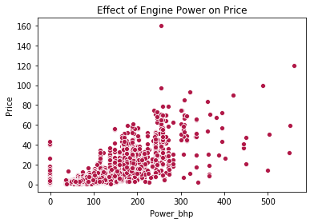

```python
sns.scatterplot(data=data, x='Power_bhp', y='Price', color=red2)
plt.title('Effect of Engine Power on Price');
```

## Alternative Approach: Regplot

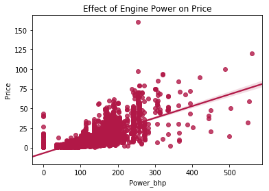

```python
sns.regplot(data=data, x='Power_bhp', y='Price', color=red2, fit_reg=True)
plt.title('Effect of Engine Power on Price');
```

## Log Transform

Sometimes having a log transform on one variable can capture better pattern

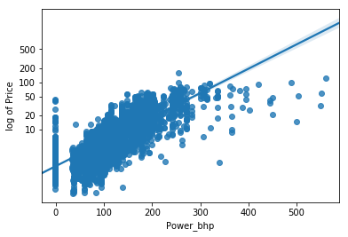

```python
def log_trans(x, inverse = False):
    if not inverse:
        return np.log10(x)
    else:
        return np.power(10, x)

sns.regplot(data['Power_bhp'], data['Price'].apply(log_trans))
tick_locs = [10, 20, 50, 100, 200, 500]
plt.yticks(log_trans(tick_locs), tick_locs);
plt.ylabel('log of Price');
```

## In Above Plot:

**At lower values, log of Price seems to have a good linear relation with Power_bhp**

By the way, did you notice the clutter in the graph? Well that's the next thing we will address - **Overplotting**

## Overplotting - Overplotting, Transparency, and Jitter

If we have a very large number of points to plot OR our numeric variables are discrete-valued, then it is possible that using a scatterplot straightforwardly will not be informative. The visualization will suffer from overplotting, where the high amount of overlap in points makes it difficult to see the actual relationship between the plotted variables.

**Check out the next subslide to understand the issues**

## Examples of Overplotting?

#### Having discrete numerical values

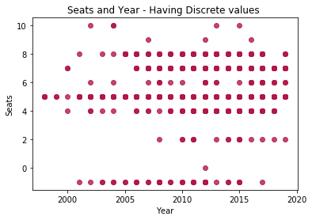

```python
sns.regplot(data=data, x='Year', y='Seats', color=red2, fit_reg=False)
plt.title('Seats and Year - Having Discrete values ');
```

### Having too many values

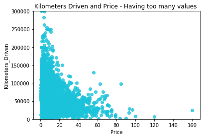

```python
sns.regplot(data=data, x='Price', y='Kilometers_Driven', color=blue3, fit_reg=False)
plt.title('Kilometers Driven and Price - Having too many values ');
plt.ylim(-1, 300000);
```

### Adding Transperacy

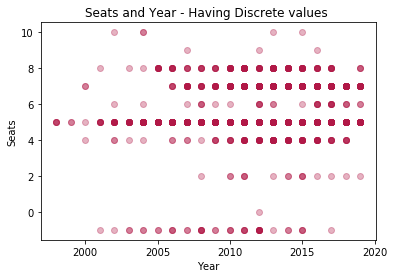

```python
# Adding some transperacy
sns.regplot(data=data, x='Year', y='Seats', color=red2, fit_reg=False, scatter_kws = {'alpha' : 1/3})
plt.title('Seats and Year - Having Discrete values ');
```

### Adding Jitter

- As an alternative or companion to transparency, we can also add jitter to move the position of each point slightly from its true value.
- The jitter settings will cause each point to be plotted in a uniform ±0.1 (e.g below) range of their true values

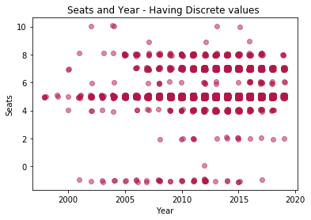

```python
# Adding some transperacy and jitter
sns.regplot(data=data, x='Year', y='Seats', color=red2, fit_reg=False,
            x_jitter=0.1, y_jitter=0.1, scatter_kws = {'alpha' : 1/2})
plt.title('Seats and Year - Having Discrete values ');
```

**Basically, whenever you have a bad scatterplot, try varying transperacy and jitter**

# Bivariate Explorations

### Case 2: Categorical vs Categorical

Navigate Down

## Three Options:

- Clustered Bar Graph
- Heatmaps
- FacetGrids

## 1. Clustered Bar Graph

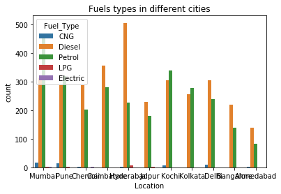

```python
# Location and Fuel Type
sns.countplot(data=data, x='Location', hue='Fuel_Type');
plt.title('Fuels types in different cities');
```

**See better plot on next slide**

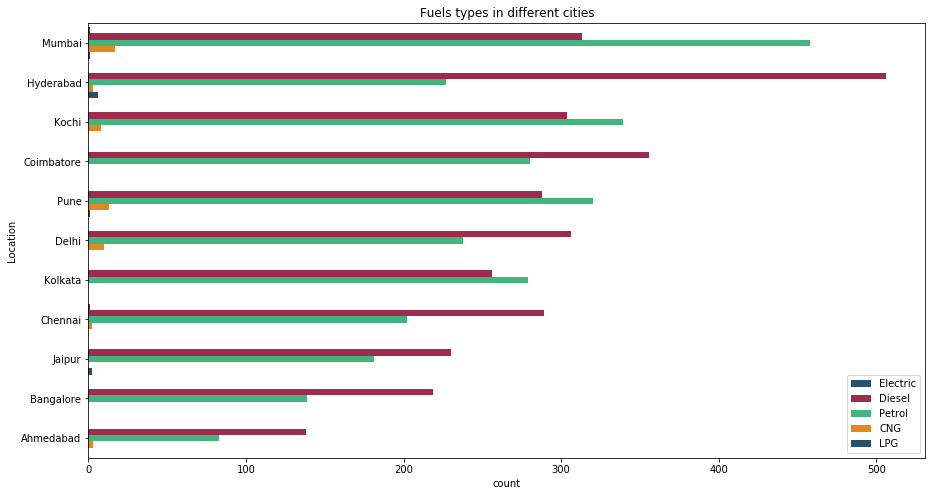

```python
plt.figure(figsize=[15, 8])
sns.countplot(data=data, y='Location', hue='Fuel_Type', order = data.Location.value_counts().index,
              hue_order = data.groupby('Fuel_Type')['Price'].mean().sort_values(ascending=False).index,
             palette=[blue1, red2, green3, 'darkorange'])
plt.legend(loc='lower right')
plt.title('Fuels types in different cities');
```

That brings us to another interesting concept:

## Color Palette

### 3 types of color Palettes:

- **Categorical Color Palettes**: When used for nominal variables
- **Sequential Color Palettes**: When used for ordinal or discrete variables
- **Diverging COlor Palettes**: Also used for ordinal or disrete, but where the values are having both positive and negative trends.

Please read [this](https://seaborn.pydata.org/tutorial/color_palettes.html) before proceeding.

P.S: We used a categorical color palette in the above plot

## Sequential Color Palette Example

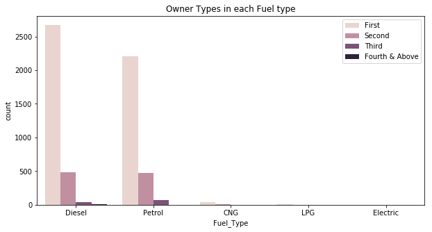

```python
plt.figure(figsize=[10, 5])
sns.countplot(data=data, x='Fuel_Type', hue='Owner_Type', order = data.Fuel_Type.value_counts().index,
              hue_order = ['First', 'Second', 'Third', 'Fourth & Above'],
             palette=sns.cubehelix_palette(4))
plt.legend(loc='upper right')
plt.title('Owner Types in each Fuel type');
```